# Business-Case-Apollo-Hospitals-Hypothesis-Testing

# Performing Mann-Whitney U Test to check whether hospitalization charges for smokers is greater than non-smokers.

H0 : mean hospitalization charges for smoker is less than mean hospitalization charges for non-smoker.

Ha : mean hospitalization charges for smoker is greater than mean hospitalization charges for non-smoker.

significance level (alpha) = 0.05

```python
alpha = 0.05
test_stats,p_value = mannwhitneyu(smokers,non_smokers)
if(p_value <alpha):
    print("Reject the null hypothesis",p_value)
else:
    print("Fail to reject NULL hypothesis",p_value)
```

```
Reject the null hypothesis 5.812122187753925e-130
```

# Conclusion

1. Hence we conclude that hospitalization charges for smokers are more than non-smokers.
2. We can also say that smokers have high chances of high hospital charges.

# Performing Hypothesis test to check whether viral load for male & female is same or not

```python
data.head()
```

|  | age | sex | smoker | region | viral load | severity level | hospitalization charges |
| --- | --- | --- | --- | --- | --- | --- | --- |
| 0 | 19 | female | yes | southwest | 9.30 | 0 | 42212.0 |
| 1 | 18 | male | no | southeast | 11.26 | 1 | 5866.1 |
| 2 | 28 | male | no | southeast | 11.00 | 3 | 11124.0 |
| 3 | 33 | male | no | northwest | 7.57 | 0 | 54961.0 |
| 4 | 32 | male | no | northwest | 9.63 | 0 | 9667.0 |

```python
viral_load_male = data.loc[data['sex']=='male']['viral load']
viral_load_female = data.loc[data['sex']=='female']['viral load']
```

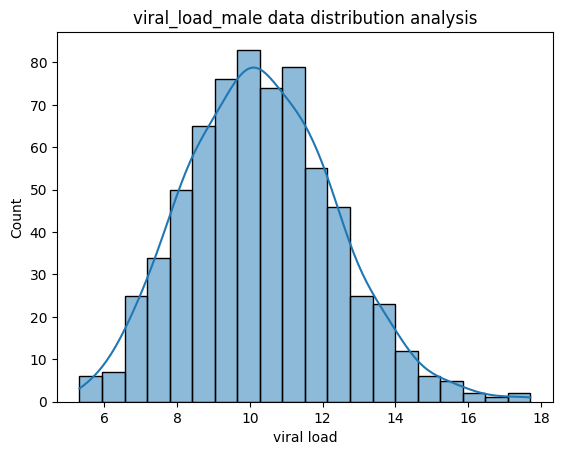

```
kurtosis for viral_load_male:  0.12465081339501571
```

```python
plot_histogram(viral_load_male,'viral_load_male data distribution analysis',bins,kde=True)
print('kurtosis for viral_load_male: ',kurtosis(viral_load_male, bias=False))
```

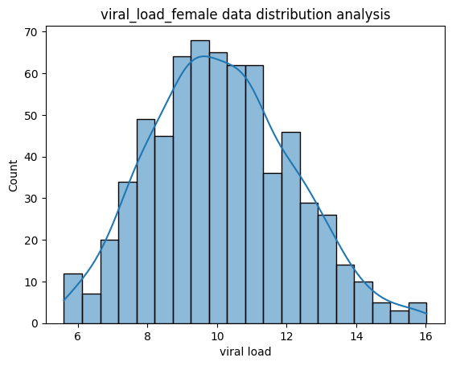

```
kurtosis for viral_load_female:  -0.2508612402509347
```

```python
plot_histogram(viral_load_female,'viral_load_female data distribution analysis',bins,kde=True)
print('kurtosis for viral_load_female: ',kurtosis(viral_load_female, bias=False))
```

# Performing Two-sample t-test Test to check whether viral load for male & female is same or not

H0 : mean viral load for female is equal mean viral load for male.

Ha : mean viral load for female is not equal mean viral load for male.

significance level (alpha) = 0.05

```python
alpha = 0.05
test_stat,p_value = ttest_ind(viral_load_female,viral_load_male,alternative='two-sided')
if(p_value <alpha):
    print("Reject the null hypothesis",p_value)
else:
    print("Fail to reject NULL hypothesis",p_value)
```

```
Fail to reject NULL hypothesis 0.0901735841670204
```

# Conclusion

Above analysis concludes that viral load is same for both the genders, hence we can say irrespective of gender viral load is same for both population